# Introdução

Análise de dados com modelos lineares em R

Nicholas A. C. Marino

github.com/nacmarino/metodosR

## Tipos de Modelos

- Existem dois tipos gerais de modelos que normalmente utilizamos:
  - Modelos lineares: os parâmetros do modelo ($\beta$<sub>0</sub>, $\beta$<sub>1</sub>,…, $\beta$<sub>n</sub>) são lineares, embora as variáveis preditoras (x<sub>1</sub>, x<sub>2</sub>,…,x<sub>n</sub>) possam não ser.
  - Modelos não-lineares: os parâmetros do modelo ($\beta$<sub>0</sub>, $\beta$<sub>1</sub>,…, $\beta$<sub>n</sub>) não são lineares. Por exemplo: *y* = $\beta$<sub>0</sub> * x<sup>$\beta$<sub>1</sub></sup>.

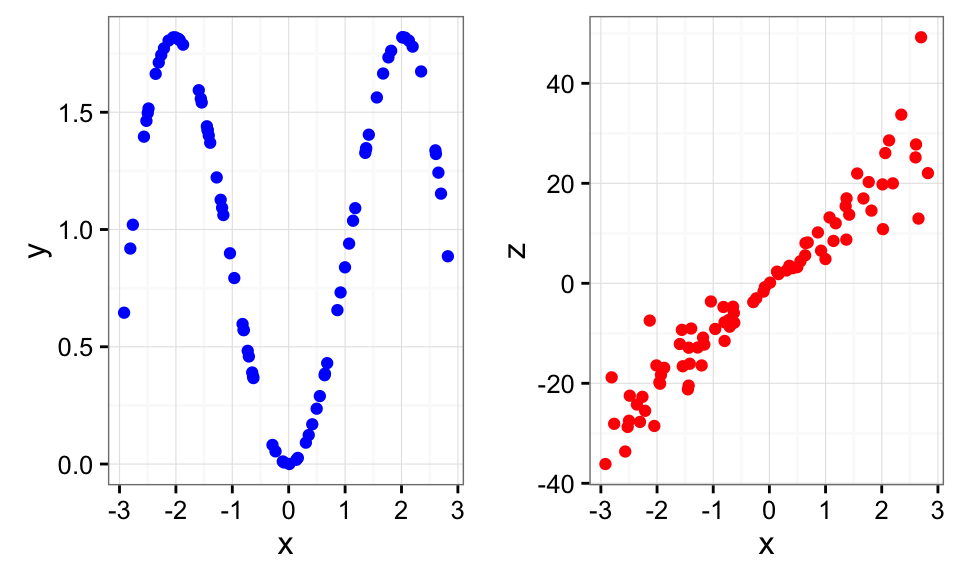

## Modelos de Regressão em R

- Existem várias funções disponíveis para rodarmos estes modelos:
  - Modelos lineares:
    - `base::lm`, `base::glm`
    - `nlme::lme`, `nlme::gls`
    - `lme4::lmer`, `lme4::glmer`
    - `gam::gam`
  - Modelos não-lineares:
    - `stats::nls`, `stats:loess`
    - `nlme::gnls`
    - `gnm::gnm`
    - `gam::gam`

## Modelos de Regressão em R

- A escolha do modelo e da função dependem da sua pergunta e dos dados que você possui:
  - Qual a natureza da relação entre sua variável resposta e as variáveis preditoras?
  - Você possui somente variáveis fixas, ou variáveis aleatórias também?
  - Você possui medidas repetidas nos mesmos indivíduos ou elas são independentes?
  - A variância é homogênea?
  - Que tipo de distribuição segue seus dados?

## Modelos Lineares em R

- Serão o nosso foco aqui.
- Rodar um modelo é parte ciência, parte arte:
  - O modelo segue sua pergunta e/ou desenho experimental;
  - Não existe o modelo certo, mas sim o que se adequa aos seus dados;
  - Você não vai ter apenas um modelo para trabalhar, mas vários modelos possíveis (eu normalmente rodo > 30 modelos para cada variável resposta nos meus trabalhos);
  - Achar o modelo adequado vem primeiro, a significância (estatística) do que está dentro dele vem depois.

## Passo-a-passo (minha fórmula)

> 1. Saber o que quero fazer;
> 2. Visualizar os dados e relação entre eles;
> 3. Descobrir o tipo de distribuição da minha variável resposta;
> 4. Estabelecer um modelo nulo;
> 5. Criar um modelo:
>    - adicionando uma variável de interesse por vez; ou,
>    - com todas as variáveis de interesse de uma vez.
> 6. Comparar com o modelo nulo;
> 7. Adicionar/remover variáveis do modelo;
> 8. Comparar os novo(s) modelo(s);
> 9. Determinar o modelo mais provável;
> 10. Validar modelo final;
> 11. Testar significância dos termos no modelo;
> 12. Fazer pós-testes, se necessário.